# ENGR 4411: Physical Acoustics

### Chapter 1 Homework

### DUE: Friday, Feb 6, 2026 at 5PM

Any problems marked with [*] are potential sources for quiz questions. Google Gemini was used as a quick search engine, math solver, and helped with some conceptual understanding. Copilot in VS code did the code in problem 3.

### Problem 1:

For the function $f(x) = e^{x}$ plot the funciton on the interval between [0, 1]. Add plots for the Taylor series expansion of this function. Start with one term, then the first two terms, then the first three terms, etc. For example: $f_{1}(x) = 1, f_{2}(x) = 1 + x, f_{3}(x) = 1 + x + \frac{x^{2}}{2}, and f_{4}(x) = 1 + x + \frac{x^{2}}{2} + \frac{x^{3}}{6}$. Repeat the process with the function $f(x) = \sin(x)$ on a separate plot.

### Problem 1 Solution:

This took some work because I wanted to do this code without AI. When I got done with the code I asked Copilot to do it so that I could compare results. With that I added in some things that copilot did to make mine look better.

I had to relearn the Taylor series expansion formula and how to do it. To save time though I ended up looking up what the Taylor expansion of sin(x) was.

Anyways here are the code for this problem. The first set of code is the $f(x) = e^{x}$ part. The second set is for $f(x) = \sin{x}$.

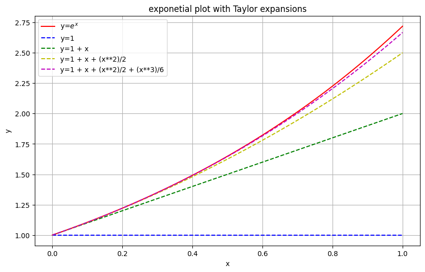

```python
import matplotlib.pyplot as plt
import numpy as np

x = np.linspace(0, 1, 100)
y = np.exp(x)
y1 = np.ones_like(x) # y = 1
y2 = 1 + x
y3 = 1 + x + (x**2)/2
y4 = 1 + x + (x**2)/2 + (x**3)/6
plt.figure(figsize=(10, 6))
plt.plot(x, y, linestyle='-', color='r', label='y=$e^x$')
plt.plot(x, y1, linestyle='--', color='b', label='y=1')
plt.plot(x, y2, linestyle='--', color='g', label='y=1 + x')
plt.plot(x, y3, linestyle='--', color='y', label='y=1 + x + (x**2)/2')
plt.plot(x, y4, linestyle='--', color='m', label='y=1 + x + (x**2)/2 + (x**3)/6')
plt.title('exponetial plot with Taylor expansions')
plt.xlabel('x')
plt.ylabel('y')
plt.legend()
plt.grid(True)
plt.show()
```

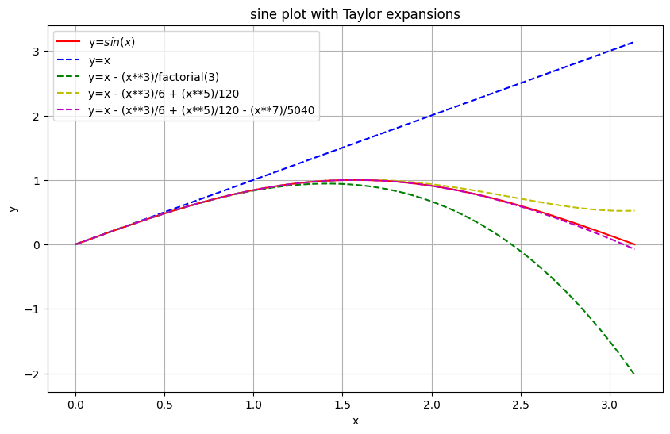

```python
import matplotlib.pyplot as plt
import numpy as np
from math import factorial
import math

x = np.linspace(0, math.pi, 100)
y = np.sin(x)
y1 = x
y2 = x - (x**3)/factorial(3)
y3 = x - (x**3)/factorial(3) + (x**5)/factorial(5)
y4 = x - (x**3)/factorial(3) + (x**5)/factorial(5) - (x**7)/factorial(7)
plt.figure(figsize=(10, 6))
plt.plot(x, y, linestyle='-', color='r', label='y=$sin(x)$')
plt.plot(x, y1, linestyle='--', color='b', label='y=x')
plt.plot(x, y2, linestyle='--', color='g', label='y=x - (x**3)/factorial(3)')
plt.plot(x, y3, linestyle='--', color='y', label='y=x - (x**3)/6 + (x**5)/120')
plt.plot(x, y4, linestyle='--', color='m', label='y=x - (x**3)/6 + (x**5)/120 - (x**7)/5040')
plt.title('sine plot with Taylor expansions')
plt.xlabel('x')
plt.ylabel('y')
plt.legend()
plt.grid(True)
plt.show()
```

### Problem 2

The Lennard-Jones potential, sometimes known as the “6-12 potential,” describes the interaction of two inert gas atoms as a function of their separation and is useful in calculations of scattering or determination of the temperature of condensation from a gas to a liquid. It was first proposed by John Lennard-Jones in 19241 and is given by,$$U(r) = 4\epsilon [(\frac{\sigma}{r})^{12} - (\frac{\sigma}{r})^{6}]$$ The term proportional to $r^{12}$ represents an empirical fit to the hard-core repulsion produced by the Pauli exclusion principle at short ranges when the atoms are close enough together that the electron orbitals overlap. The $r^{6}$ term represents the van der Waals attraction due to mutual interactions of the fluctuating dipole moments. A plot of the Lennard-Jones potential is illustrated below.

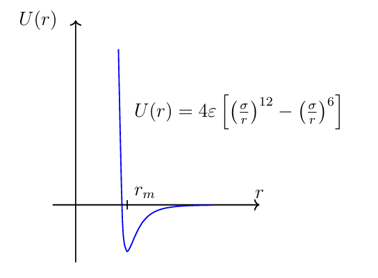

Do the following:

1. Plot the Lennard-Jones potential as a function of $\frac{\sigma}{r}$ in the range (0, 2.5) as illustrated above. For the purposes of the plot let $\epsilon = \sigma = 1$. HINT: You may have to adjust your axes scale and plot range to see this clearly.
2. Determine the equilibrium separation of two atoms, $r_{m}$, in terms of $\sigma$ and $\epsilon$. You should find: $r_{m} = \sigma 2^{\frac{1}{6}}$.
3. Expand the Lennard-Jones potential in a Taylor series around $r_{m}$ and determine the effective spring constant for small oscillations about the equilibrium position. You should find $k_{eff} = 2\epsilon (\frac{6}{r_{m}})^{2}$.

### Problem 2 Solution (Code)

This will take some work so the code might not be perfect. Im starting with the code from problem 1 and changing it as it already has the bones for a plot.

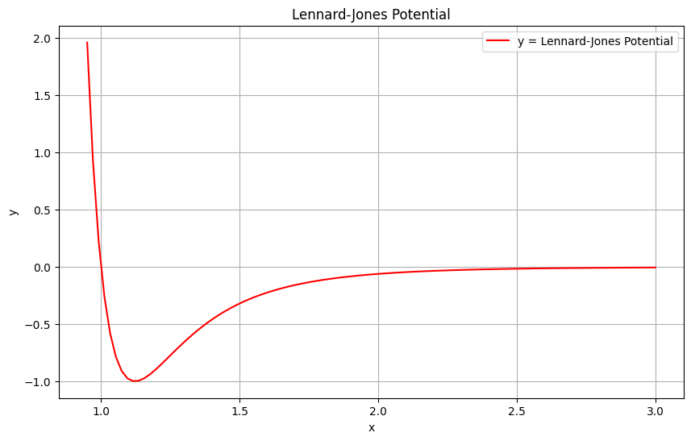

```python
import matplotlib.pyplot as plt
import numpy as np
from math import factorial
import math

x = np.linspace(0.95, 3, 100) # this will be the r term
e = s = 1
c = s / x
y = (4 * e) * ((c)**12 - (c)**6)
#y1 = x
#y2 = x - (x**3)/factorial(3)
#y3 = x - (x**3)/factorial(3) + (x**5)/factorial(5)
#y4 = x - (x**3)/factorial(3) + (x**5)/factorial(5) - (x**7)/factorial(7)
plt.figure(figsize=(10, 6))
plt.plot(x, y, linestyle='-', color='r', label='y = Lennard-Jones Potential')
#plt.plot(x, y1, linestyle='--', color='b', label='y=x')
#plt.plot(x, y2, linestyle='--', color='g', label='y=x - (x**3)/factorial(3)')
#plt.plot(x, y3, linestyle='--', color='y', label='y=x - (x**3)/factorial(3) + (x**5)/factorial(5)')
#plt.plot(x, y4, linestyle='--', color='m', label='y=x - (x**3)/factorial(3) + (x**5)/factorial(5) - (x**7)/factorial(7)')
plt.title('Lennard-Jones Potential')
plt.xlabel('x')
plt.ylabel('y')
plt.legend()
plt.grid(True)
plt.show()
```

### Problem 2 Solution Continued (Conceptual)

#### 2.

I'm guessing this needs to be done by taking the derivative with respect to r and then setting it equal to 0. Lets find out.

Our equation is of course: $$U(r) = 4\epsilon [(\frac{\sigma}{r})^{12} - (\frac{\sigma}{r})^{6}]$$

We can simply use the power rule to derive this. After performing this we get: $$\frac{dU}{dr} = 4\epsilon [-12\frac{\sigma^{12}}{r^{13}} + 6\frac{\sigma^{6}}{r^{7}}]$$

Now we can set this equal to 0 and find our minimum. Since $4\epsilon$ is distributed in the equation it will cancel after moving terms to the other side. We are then left with: $$12\frac{\sigma^{12}}{r^{13}} = 6\frac{\sigma^{6}}{r^{7}}$$

We can then divide by 6 on both sides. This gives us a 2 on the left and a 1 on the right. Now we can distribute our r and $\sigma$ terms to the left side. The exponents will subtract. This leaves us with: $$2\frac{\sigma^{6}}{r^{6}} = 1$$

Moving r over to the right side: $$2\sigma^{6} = r^{6}$$

And now we can fully simplify by taking the exponent away from r. This leaves us with the expected equation: $$r_{m} = \sigma 2^{\frac{1}{6}}$$

#### 3.

So I originally thought this meant expanding the full left side of the equation. I put it off for awhile then I thought "why not just expand the right side dummy". Also the explanation after lab class helped me come to this thought. Anyways lets see what we can do.

The Taylor series expansion looks like this: $$f(x) = f(x) + f^{'}(a)\frac{x-a}{1!} + f^{"}(a)\frac{(x-a)^{2}}{2!} + f^{'''}(a)\frac{(x-a)^{3}}{3!}......$$

We can simply convert this to our specific problem thankfully. The a's get converted into the $r_{m}$ term: $$U(r) = U(r) + U^{'}(r_{m})\frac{r-r_{m}}{1!} + U^{"}(r_{m})\frac{(r-r_{m})^{2}}{2!} + U^{'''}(r_{m})\frac{(r-r_{m})^{3}}{3!}$$

I wrote these equations down in terms of only the Taylor series expansion so initially I didn't get where the spring constant comes in. Once I tried to simplify stuff I found out that you can write the 2! as 1/2. Also the third term felt excessive so I got rid of it. Anyways the term with the second derivative of U(r) looks suspicious. $\frac{1}{2}U^{"}(r_{m})(r-r_{m})^{2}$ looks exactly like the potential energy of a spring $U = \frac{1}{2}kx^{2}$. Since this is the case all we need to do is find the second derivative and then algebrafy it down to something simple and clean. We can start with the derivative that we got earlier: $$\frac{dU}{dr} = 4\epsilon [-12\frac{\sigma^{12}}{r^{13}} + 6\frac{\sigma^{6}}{r^{7}}]$$

Applying the power rule again we get something like this: $$U^{''}(r_{m}) = 4\epsilon[156\frac{\sigma^{12}}{r^{14}} - 42\frac{\sigma^{6}}{r^{8}}]$$

Now that we have that we can simplify it like we did earlier. Okay simplifying this was really difficult. I also realized that symbolab is useless sometimes. After simplifying on paper we get: $$k_{eff} = 2\epsilon (\frac{6}{r_{m}})^{2}$$

This is what we were looking for!

### Problem 3

The sawtooth waveform illustrated below occurs when nonlinear effects distort a sinusodial sound wave into a fully developed shock wave.

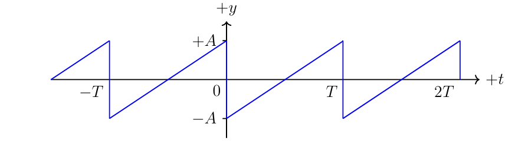

1. Show that one cycle of a sawtooth wave, with period T and amplitude A, is expressed algebraically as $$y(t) = \frac{2A}{T}t - A$$
2. Determine the Fourier coefficients $A_{0}$, $A_{n}$, and $B_{n}$. Show all work.
3. Write the expression for the sawtooth as a superposition of Fourier components with frequencies $f_{n} = \frac{n}{T}$, where n = 1,2,3....
4. Plot the three largest Fourier components as well as their sum on the same graph. Include a plot of $y(t) = \frac{2A}{T}t − A$. Let $A = 1$ and $T = 3$ for the plot.

### Problem 3 Solution (Conceptual):

#### 1.

Its late and im tired, but here goes. Looking at the wave, at t=0 the amplitude is -A. At t=T the amplitude is A. Lower case t represents the x axis where amplitude shows the y axis. We need to find the slope of this. If slope is rise over run then the rise is a total of 2A and the run is the period T. So the slope m is $\frac{2A}{T}$. This depends on time so we can think of x as just the time t. Looking at the image above we know that the wave hits the y axis at t = 0. This means that our equation becomes $$y(t) = mt + b, \space\space y(t) = \frac{2A}{T}t-A$$

#### 2.

Page 14 of the Acoustics book provided shows the formulas for $A_{0}, A_{n}, and B_{n}$.

Lets see what we can do about $A_{0}$. Normally the first term in this is 1/T, but for this case it is 2/T since the area above 0 is the same below giving us the 2/T: $$A_{0} = \frac{2}{T}\int_{0}^{T} (\frac{2A}{T}t-A) \, dt$$

After integration we get this: $$\frac{2}{T}[(\frac{AT^2}{2T}-AT) - (\frac{A0^2}{2T} - A0)]$$

Of course everything after the minus sign is 0. After you simplify this down you find that $A_{0} = 0$. If you want the full steps I took I have some scribbles in my notebook from this.

For $A_{n}$ we can write this crazy integral: $$A_{n} = \frac{2}{T}\int_{0}^{T} (\frac{2A}{T}t-A)\cos{(nw_{0}t)} \, dt$$

Okay maybe its not that bad. I could just be out of practice. Something to remember is that $w_{0} = \frac{2\pi}{T}$. What im thinking is that if we are going to integrate this from 0 to T then we are basically integrating it from 0 to $2\pi$. If cos(0) and $\cos(2\pi)$ both equal 1, then after integration everything will be canceled out. That saved me alot of time.

For $B_{n}$ though im afraid its a different story. The integral we start with is $$B_{n} = \frac{2}{T}\int_{0}^{T} (\frac{2A}{T}t-A)\sin{(nw_{0}t)} \, dt$$

We unfortunatly have to integrate by parts. Doing some research the formula for this is $uv - \int v du$. Lets call u --> $u = (\frac{2A}{T}t-A)$ and dv as --> $dv = \sin(nw_{0}t)dt$. Now after deriving and integrating we can get du and v: $$du = \frac{2A}{T}dt, \space\space v = -\frac{1}{nw_{0}t}\cos(nw_{0}t)$$

Now we can plug in all the mess following the formula: $$B_{n} = (\frac{2A}{T}t-A)(-\frac{1}{nw_{0}t}\cos(nw_{0}t)) - \int_{0}^{T} (-\frac{1}{nw_{0}t}\cos(nw_{0}t))(\frac{2A}{T}dt,)$$

Okay now this is where I admit defeat. I tried a little bit of this integral and just gave up so I gave AI a picture of it and some context and it told me that I was correct at this point. Basically after integration by parts you use the fact that $w_{0}T = 2\pi$ to simplify things down. Also during this I remembered that the last part looks like the calculation of A_n. This goes to 0 so we can cross this out. After evaluating over a full period AI gave me the answer: $$B_{n} = -\frac{2A}{n\pi}$$

This result can help us to complete part 3 of this question.

#### 3.

Since $A_{0} = 0$ and $A_{n} = 0$ we can take equation 1.35 from the book and write down the summation for this wave: $$y(t) = \sum_{n=1}^{\infty} B_{n}\sin(nwt)$$ Rewriting so that we can get this in terms of frequency $f_{n}$ and plugging in our result for $B_{n}$ we have: $$y(t) = \sum_{n=1}^{\infty} -\frac{2A}{n\pi}\sin(2\pi \frac{n}{T}t)$$

All we have to do now is plug in the values for n = 1,2,3 and add them together. Lets simplify our equation before we do this: $$y(t) = -\frac{2A}{\pi} \sum_{n}^{\infty}\frac{1}{n}\sin(\frac{2\pi n}{T}t)$$

Now we can plug in the values of n. After some work we get the first three n terms summed together as: $$y(t) = -\frac{2A}{\pi}[\sin(\frac{2\pi}{T}t) + \frac{1}{2}\sin(\frac{4\pi}{T}t) + \frac{1}{3}\sin(\frac{6\pi}{T}t)]$$

The pattern is clear here and I think this looks good. Lets move to plottin these.

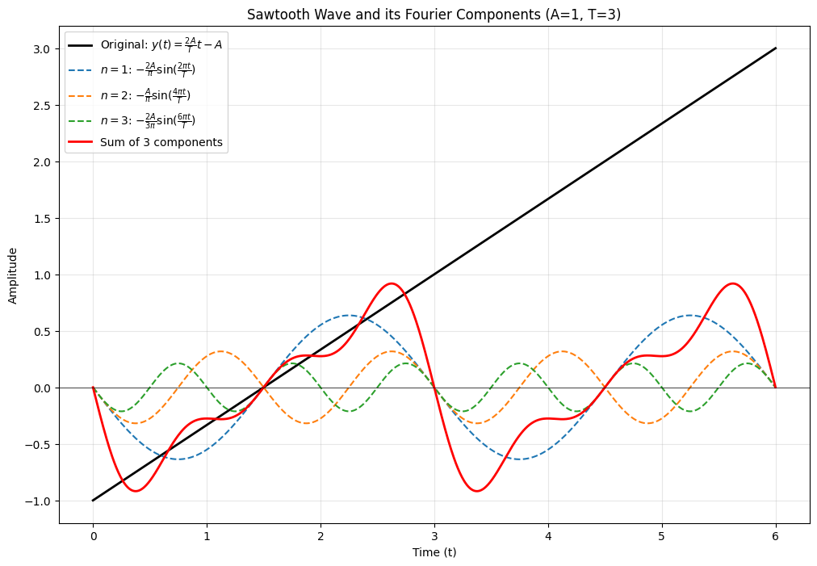

```python
#This code was made by Copilot in VSCode based on results from conceptual questions


import matplotlib.pyplot as plt
import numpy as np

# Parameters
A = 1
T = 3

# Time array - plot over a few periods
t = np.linspace(0, 2*T, 1000)

# Original sawtooth wave
y_sawtooth = (2*A/T)*t - A

# Three largest Fourier components (n=1, 2, 3)
# B_n = -2A/(n*pi)
# Component: B_n * sin(2*pi*n*t/T)

y1 = -(2*A/np.pi) * np.sin(2*np.pi*t/T)
y2 = -(2*A/(2*np.pi)) * np.sin(4*np.pi*t/T)
y3 = -(2*A/(3*np.pi)) * np.sin(6*np.pi*t/T)

# Sum of the three components
y_sum = y1 + y2 + y3

# Plot
plt.figure(figsize=(12, 8))

plt.plot(t, y_sawtooth, 'k-', linewidth=2, label='Original: $y(t) = \\frac{2A}{T}t - A$')
plt.plot(t, y1, '--', linewidth=1.5, label='$n=1$: $-\\frac{2A}{\\pi}\\sin(\\frac{2\\pi t}{T})$')
plt.plot(t, y2, '--', linewidth=1.5, label='$n=2$: $-\\frac{A}{\\pi}\\sin(\\frac{4\\pi t}{T})$')
plt.plot(t, y3, '--', linewidth=1.5, label='$n=3$: $-\\frac{2A}{3\\pi}\\sin(\\frac{6\\pi t}{T})$')
plt.plot(t, y_sum, 'r-', linewidth=2, label='Sum of 3 components')

plt.xlabel('Time (t)')
plt.ylabel('Amplitude')
plt.title('Sawtooth Wave and its Fourier Components (A=1, T=3)')
plt.legend(loc='best')
plt.grid(True, alpha=0.3)
plt.axhline(y=0, color='k', linestyle='-', linewidth=0.5)
plt.show()
```

#### Problem 3 Coding Discussion:

As we can see from the plot, the sum starts to resemble a sawtooth waveform. Though not perfect of course we'd need more components to get it as close as possible.

### Problem 4:

Given the best estimate and probable range state the following in standard form: $x_{best} ± δx$

1. Best estimate length is 210 cm and probable range is between 205 and 215 cm.
2. Best estimate of length is 36 mm and probable range is between 35.5 and 36.5 mm.
3. Best estimate of voltage is 5.3 volts and probable range is 5.2 to 5.4 volts.
4. Best estimate of time is 2.4 sec and probable range is 2.3 to 2.5 sec.

### Problem 4 Solution

1. $210 \pm 5 cm$
2. $36.0 \pm 0.5 mm$ Or $36 \pm 1 mm$
3. $5.3 \pm 0.1 V$
4. $2.4 \pm 0.1 s$

### Problem 5 [*]

Rewrite results in clearest form with suitable significant digits:

1. $h = 5.03 \pm 0.04329 m$
2. $t = 1.5432 \pm 1 s$
3. $g = -3.21 * 10^{-19} \pm 2.67 * 10^{-20} C$
4. $\lambda = 0.000000563 \pm 0.00000007 m$
5. $p = 3.267 * 10^{3} \pm 42 g\frac{cm}{s}$
1. $h = 5.03 \pm 0.04 m$
2. $t = 1.5 \pm 1 s$
3. $g = (-3.21 \pm .27) * 10^{-19} C$
4. $\lambda = (5.6 \pm 0.7) * 10^{-7} m$
5. $p = (3.27 \pm 0.04) * 10^{3} g\frac{cm}{s}$

### Problem 6 [*]

Evaluate the following expressions where $$G(\omega) = -\frac{R_{f}}{R_{in}} \frac{1}{1 + j\frac{\omega}{\omega_{RC}}},j = \sqrt{-1}$$

1. $Re(G(\omega))$
2. $Im(G(\omega))$
3. $|G(\omega)|$
4. Determine the phase angle, $\phi$, in the expression: $G(\phi) = |G(\omega)|e^{j\phi}$

### Problem 6 Solution

So of course we went over complex numbers in class, but to relearn to do things I have to sit down and do them myself. After some research I learned that $i^{2} = -1$. Like duhhh Caleb. The point is that it will help me solve this problem by reminding me of some of the basics of how complex numbers work.

I also relearned that when you have i in the denominator its a good idea to multiply everything by the complex conjugate. We will need to do this to find the real and imaginary parts to this problem. Just so I have this here, I am going to put an example in this.

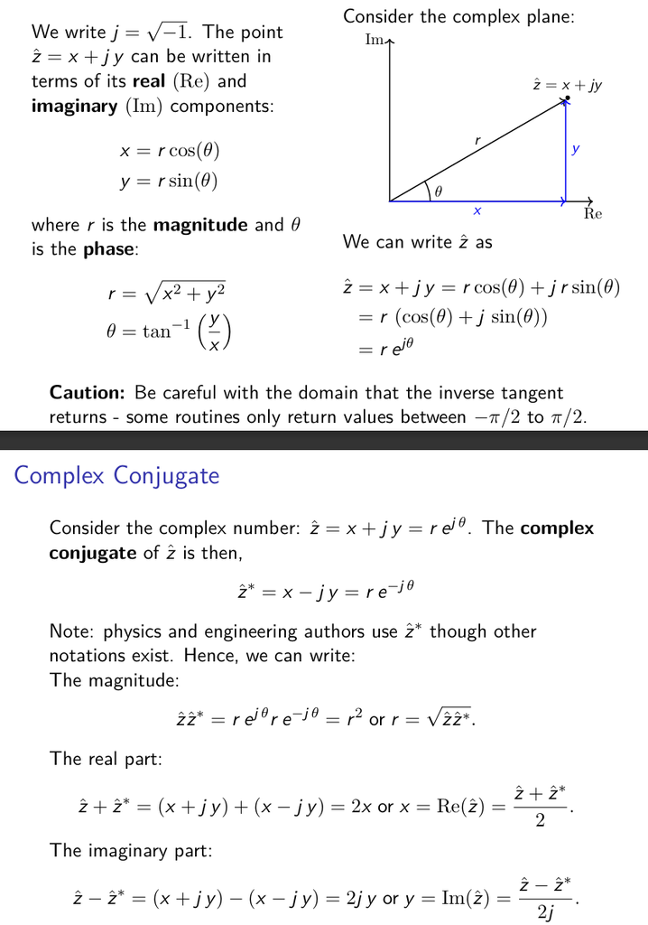

1. Real part (Re)

$$ Re(G(\omega)) = -\frac{R_{f}}{R_{in}}(\frac{1}{1-(\frac{\omega}{\omega_{RC}})^{2}})$$

2. Imaginary part (IM)

$$ Im(G(\omega)) = (\frac{R_{f}}{R_{in}})(\frac{\frac{\omega}{\omega_{RC}}}{1+(\frac{\omega}{\omega_{RC}})^{2}})$$

I learned something when I was trying to figure this out. The magnitude of a fraction is equal to the magnitude of the top divided by the magnitude of the botton. With this we can isolate the complex number on the bottom and apply our magnitude from the notes. Everything else is pretty easy so well focus on the complex denominator. So for this our equation is $z = 1 + jx$. Its complex conjugate is $\hat{z} = 1 - jx$. I know the z's are a little off. Anyways we can multiply these and then slap a square root over it and call it a day. $$z\hat{z} = 1 + x^{2}$$

TaDaaaaa we got rid of the complex number! Now we can write out the full equation for the magnitude: $$|G(\omega)| = |-\frac{R_{f}}{R_{in}}|*|(\frac{1}{\sqrt{1+x^{2}}})|$$

And now we have our answer after simplification and stuff.

$$|G(\omega)| = \frac{R_{f}}{R_{in}} (\frac{1}{\sqrt{1+(\frac{\omega}{\omega_{RC}})^{2}}})$$

### Problem 7

Prove Euler's formula: $e^{j\theta} = \cos{\theta} + j\sin{\theta}$ by doing the following:

1. Start with the Maclaurin series (Taylor series for $x_{0} = 0$) for the function: $e^{j\theta}$.
2. Group real and imaginary terms (keep terms up to at least $\theta^{8}$) to see the pattern clearly.
3. Identify the Maclaurin series for cos θ and sin θ.

### Problem 7 Solution:

To start this off I'm going to substitute so that $j\theta = x$ giving us the Maclaurin series of $e^{x}$.

#### 1. Now we can start.

- x = 0: $\frac{x^{0}}{0!} = 1$
- x = 1: $\frac{x^{1}}{1!} = x$
- x = 2: $\frac{x^{2}}{2!} = \frac{x^{2}}{2!}$
- And so on:

After this we get the expansion up to $\theta^{8}$ as: $$e^{x} = 1 + x + \frac{x^{2}}{2!} + \frac{x^{3}}{3!} + \frac{x^{4}}{4!} + \frac{x^{5}}{5!} + \frac{x^{6}}{6!} + \frac{x^{7}}{7!} + \frac{x^{8}}{8!}$$

Now if we plug our substitution back in we get our Maclaurin series expansion for $e^{j\theta}$: $$e^{j\theta} = 1 + j\theta + \frac{(j\theta)^{2}}{2!} + \frac{(j\theta)^{3}}{3!} + \frac{(j\theta)^{4}}{4!} + \frac{(j\theta)^{5}}{5!} + \frac{(j\theta)^{6}}{6!} + \frac{(j\theta)^{7}}{7!} + \frac{(j\theta)^{8}}{8!}$$

#### 2. Theres an interesting pattern here:

- $j^{1} = j$
- $j^{2} = -1$
- $j^{3} = -j$
- $j^{4} = 1$

This follows a behavior similar to cos and sin. I cant tell you how many times I messed up the typing for this, but anyways the expansion then becomes: $$e^{j\theta} = 1 + j\theta - \frac{(\theta)^{2}}{2!} - j\frac{(\theta)^{3}}{3!} + \frac{(\theta)^{4}}{4!} + j\frac{(\theta)^{5}}{5!} - \frac{(\theta)^{6}}{6!} - j\frac{(j\theta)^{7}}{7!} + \frac{(\theta)^{8}}{8!}$$

Now we have our imaginary numbers isolated to a few parts of the expansion. This allows me to group like terms. These then become our real and imaginary parts:

Real: $$1 - \frac{(\theta)^{2}}{2!} + \frac{(\theta)^{4}}{4!} - \frac{(\theta)^{6}}{6!} + \frac{(\theta)^{8}}{8!}$$

Imaginary: $$j(\theta - \frac{(\theta)^{3}}{3!} + \frac{(\theta)^{5}}{5!} - \frac{(j\theta)^{7}}{7!})$$

#### 3. What is cos and what is sin in terms of RE and IM?

From studying the notes I know that cos represents the real part, and sin represents the imaginary part. After looking up the Maclaurin series expansion for cos and sin I can confirm that the real part is indeed cos and vise-versa.

cos: $$\cos{\theta} = 1 - \frac{(\theta)^{2}}{2!} + \frac{(\theta)^{4}}{4!} - \frac{(\theta)^{6}}{6!} + \frac{(\theta)^{8}}{8!}$$

sin: $$\sin{\theta} = j(\theta - \frac{(\theta)^{3}}{3!} + \frac{(\theta)^{5}}{5!} - \frac{(\theta)^{7}}{7!})$$

### Problem 8

Prove the following relationships:

1. $\cos{\theta} = \frac{e^{j\theta} + e^{-j\theta}}{2}$
2. $\sin{\theta} = \frac{e^{j\theta} - e^{-j\theta}}{2j}$

### Problem 8 Solution:

I want to do this by simply plugging in values for $\theta$, but thats probably not the way I'm being asked to prove these relationships. Just by plugging in radian values I can see that these statements are true.

For Cos: $$\frac{e^{j\pi} + e^{-j\pi}}{2} = -1, \space \space \cos{\pi} = -1$$ For sin: $$\frac{e^{j\pi} - e^{-j\pi}}{2j} = 0, \space \space \sin{\pi} = 0$$